# Effects of Spanish-Language Ads

Flores, Alejandro and Alexander Coppock. “Do Bilinguals Respond More Favorably to Candidate Advertisements in English or in Spanish?” Working Paper.

- PDF

## Abstract

Candidates for political office can appeal to bilingual Americans in either English or in Spanish. We investigate the consequences of this choice by exploiting a unique opportunity afforded by the 2016 Republican presidential primary. Jeb Bush, who is fluent in Spanish and English, produced otherwise identical versions of an advertisement in both languages. We find that bilinguals who were assigned to view the Spanish-language version increased their support for Bush by 6 percentage points in the primary and by 5 percentage points in a hypothetical matchup against Hillary Clinton in the general. We explain our results in a social identity framework. Bilinguals appear to increase their support for Bush because they infer that by virtue of publicly speaking Spanish well, Bush displays an affinity with the Latino in-group. Because our design holds constant the candidate’s policy positions, we can attribute the effects on vote choice directly to the choice of language over and above other candidate attributes.

## Figure

Figure 1, showing the effects of the Spanish-language ad on Bush preference by survey language condition:

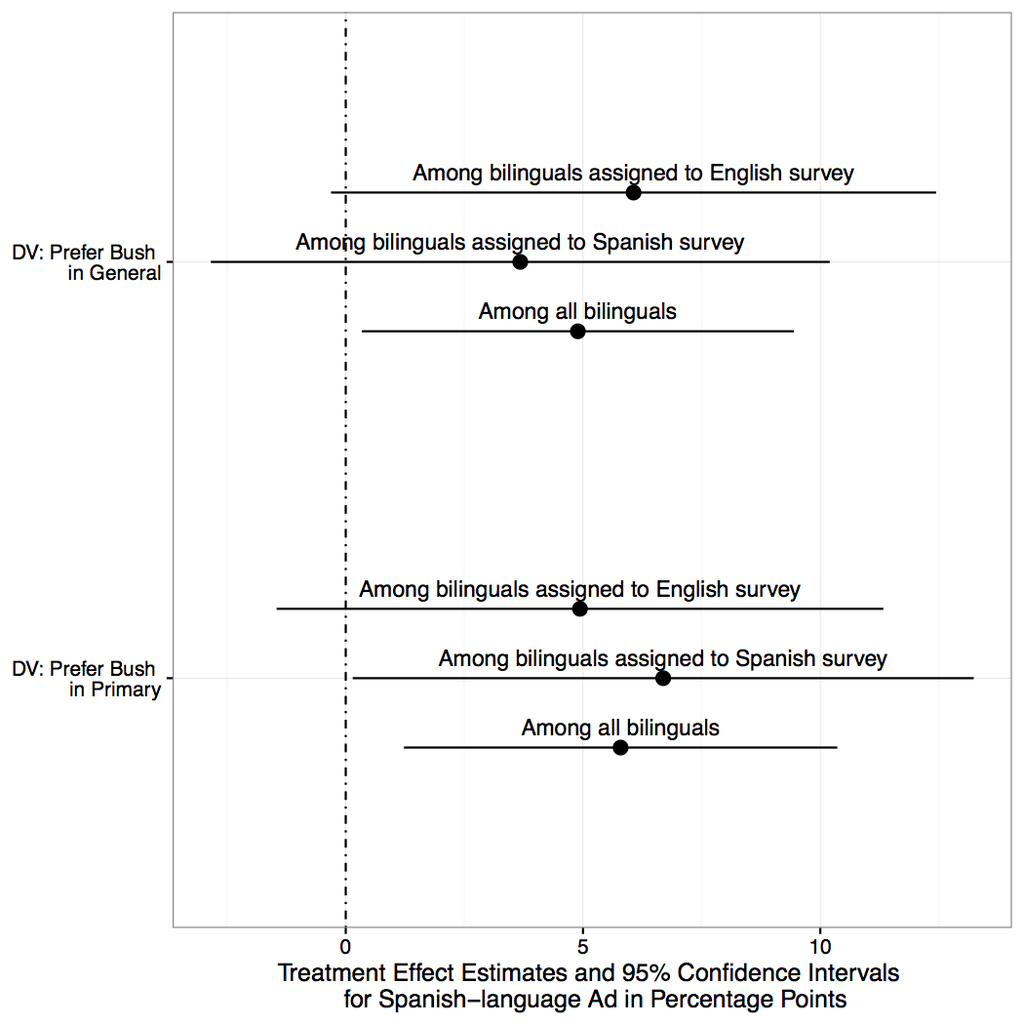

## Bibtex citation

[output not shown]